# R Notebook

Setup

```r
library(tidyverse)
library(DataExplorer)
library(ggplot2)
library(data.table)
```

Import data

```r
df <- read.csv("capstone_repository/data/ratios_return.csv")
dim(df)#10788    35
```

```
[1] 10788    35
```

```r
colnames(df)
```

```
 [1] "X"                           "Ticker"                      "SimFinId"                    "Company.Name"
 [5] "IndustryId"                  "Sector"                      "Industry"                    "Report.Date"
 [9] "Fiscal.Year"                 "Current.Ratio"               "Quick.Ratio"                 "NWC.to.Asset.Ratio"
[13] "Cash.Ratio"                  "Long.Term.Debt.Ratio"        "Liabilities.to.Equity.Ratio" "Total.Debt.Ratio"
[17] "Debt.to.Asset.Ratio"         "Interest.Coverage.Ratio"     "Cash.Coverage.Ratio"         "Return.On.Assets"
[21] "Return.On.Capital"           "Return.On.Equity"            "Operating.Profit.Margin"     "Net.Profit.Margin"
[25] "Asset.Turnover"              "Receivable.Turnover"         "Close"                       "Book.to.Market.Ratio"
[29] "Earning.Per.Share"           "Sales.Per.Share"             "Price.to.Earning.Ratio"      "Return"
[33] "Return2"                     "Return3"                     "Return4"
```

Keeps rows in Technology Sector

```r
tech <- subset(df, Sector == 'Technology')
dim(tech)# 2085   35
```

```
[1] 2085   35
```

#####################################################################Operating.Profit.Margin############################################

Outliers on the left side

```r
summary(tech$Operating.Profit.Margin)
```

```
     Min.   1st Qu.    Median      Mean   3rd Qu.      Max.
-12.07678   0.01599   0.08713   0.04513   0.17861   0.62948
```

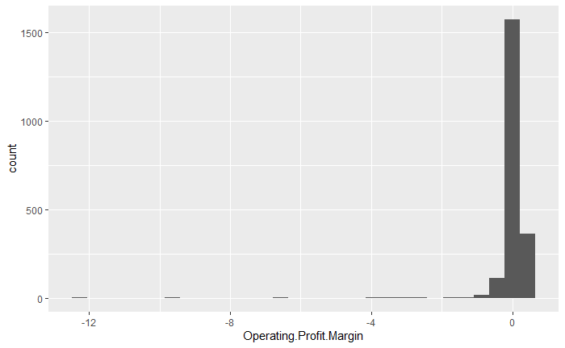

```r
#     Min.   1st Qu.    Median      Mean   3rd Qu.      Max.
#-12.07678   0.01599   0.08713   0.04513   0.17861   0.62948

#check distribuion
ggplot(tech)+ geom_histogram(aes(x=Operating.Profit.Margin))
```

After removing observation smaller than -1, the distribution is slightly left skewed most observations are around 0 we may want to try some transformations

```r
#arbitrily choose a subset
sum(tech$Operating.Profit.Margin <  -1) #23
```

```
[1] 23
```

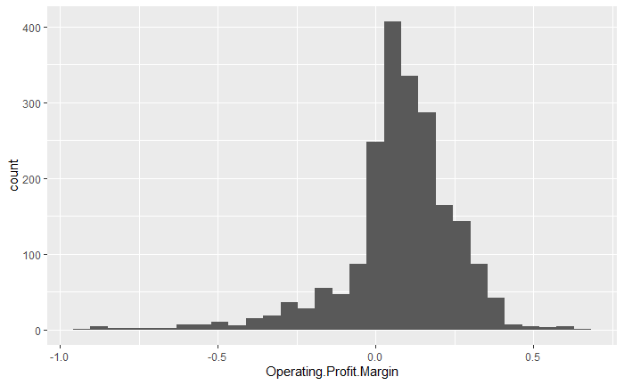

```r
ggplot(tech[tech$Operating.Profit.Margin > -1,]) + geom_histogram(aes(x = Operating.Profit.Margin))
```

Cube transformation doesn’t work

```r
#function for cube transformation
#Math.cbrt <- function(x) {
#    sign(x) * abs(x)^(1/3)
#}

#tech$Operating.Profit.Margin.cube <- Math.cbrt(tech$Operating.Profit.Margin)
#ggplot(tech[tech$Operating.Profit.Margin > -1,]) + geom_histogram(aes(x = Operating.Profit.Margin.cube)) #doesn't work
```

log transformation, doesn’t help either

```r
# #Math.log <- function(x){
#   min_x <- min(x)
#   log(x + abs(min_x) + 0.1)
# }
#
#
# tech$Operating.Profit.Margin.log <- Math.log(tech$Operating.Profit.Margin)
# summary(tech$Operating.Profit.Margin.log)
# ggplot(tech[tech$Operating.Profit.Margin > -1,]) + geom_histogram(aes(x = Operating.Profit.Margin.log)) #doesn't work
```

So we will not do any transfrmation on this data but instead remove several outliers.

```r
sd <- sd(tech$Operating.Profit.Margin) #0.4783343
mean <- mean(tech$Operating.Profit.Margin) # 0.04513398
ci <- c(mean - 3*sd, mean + 3*sd) #-1.389869  1.480137
sum(!tech$Operating.Profit.Margin %between% ci)#15 outliers
```

```
[1] 15
```

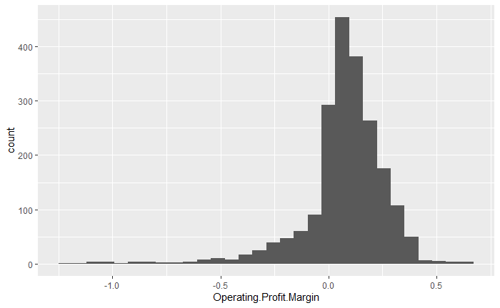

```r
#plot the histogram after removing outliers
ggplot(tech[tech$Operating.Profit.Margin %between% ci,]) + geom_histogram(aes(x = Operating.Profit.Margin))
```

Ticker and Year for outliers

```r
tech$Operating.Profit.Margin.out <- !tech$Operating.Profit.Margin %between% ci
sum(tech$Operating.Profit.Margin.out)
```

```
[1] 15
```

Summary: 1. No transformation 2. those outliers are outside 3 standard deviation from the mean

Return.On.Capital

pretty right skewed

```r
summary(tech$Return.On.Capital)
```

```
   Min. 1st Qu.  Median    Mean 3rd Qu.    Max.
-6.2459  0.1456  0.3553  0.6858  0.7676 40.5840
```

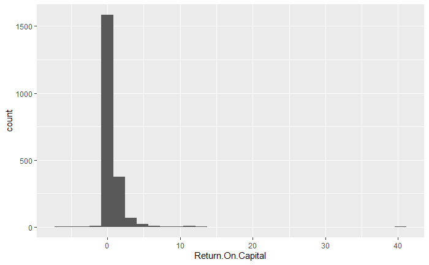

```r
#   Min. 1st Qu.  Median    Mean 3rd Qu.    Max.
#-6.2459  0.1449  0.3547  0.6844  0.7674 40.5840

#check distribuion
ggplot(tech)+ geom_histogram(aes(x=Return.On.Capital))
```

After removing observatins larger than 10, the distribution is still pretty right skewed

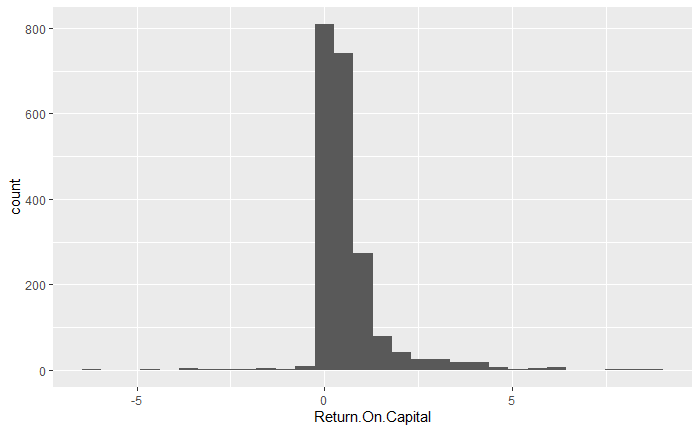

```r
#even after removing outliers the data is still pretty right skewed
ggplot(tech[tech$Return.On.Capital < 10,]) + geom_histogram(aes(x = Return.On.Capital))
```

log transformation doesn’t help

```r
#tech$Return.On.Capital.log <- Math.log(tech$Return.On.Capital)
#ggplot(tech[tech$Return.On.Capital < 10,]) + geom_histogram(aes(x = Return.On.Capital.log))
```

```r
tech$Return.On.Capital.cube <- Math.cbrt(tech$Return.On.Capital)

sd_cube <- sd(tech$Return.On.Capital.cube)
mean <- mean(tech$Return.On.Capital.cube)
ci <- c(mean - 3*sd_cube, mean + 3* sd_cube)
sum(!tech$Return.On.Capital.cube %between% ci) #still has 36 outliers
```

```
[1] 36
```

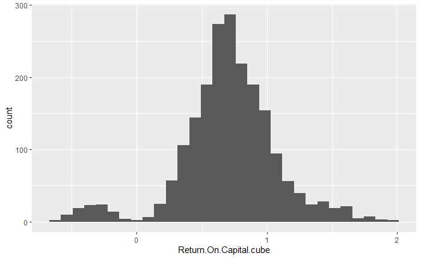

```r
#plot distribution
ggplot(tech[tech$Return.On.Capital.cube  %between% ci,]) + geom_histogram(aes(x = Return.On.Capital.cube))
```

Identify outliers

```r
tech$Return.On.Capital.out <- !tech$Return.On.Capital.cube  %between% ci
sum(tech$Return.On.Capital.out)
```

```
[1] 36
```

Summary 1. cube transformation 2. removing outliers outside3 sd

#######################################Return on Equity########################################

```r
summary(tech$Return.On.Equity)
```

```
    Min.  1st Qu.   Median     Mean  3rd Qu.     Max.
-10.9390   0.3372   0.6366   1.7279   1.2912 964.7980
```

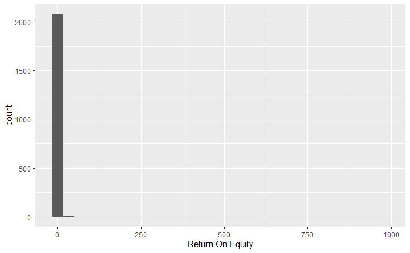

```r
#    Min.  1st Qu.   Median     Mean  3rd Qu.     Max.
#-10.9390   0.3372   0.6366   1.7279   1.2912 964.7980

#check distribuion
ggplot(tech)+ geom_histogram(aes(x=Return.On.Equity))
```

after removing several observations still 0

```r
sum(tech$Return.On.Equity > 10) #37
```

```
[1] 37
```

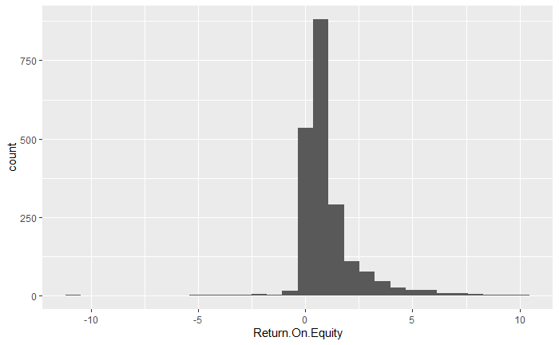

```r
ggplot(tech[tech$Return.On.Equity < 10,])+ geom_histogram(aes(x=Return.On.Equity))
```

try log transformation, doesn’t work well

```r
#tech$Return.On.Equity.log <-  Math.log(tech$Return.On.Equity)
#ggplot(tech[tech$Return.On.Equity < 10,])+ geom_histogram(aes(x=Return.On.Equity.log))
```

try cube transformation, works good

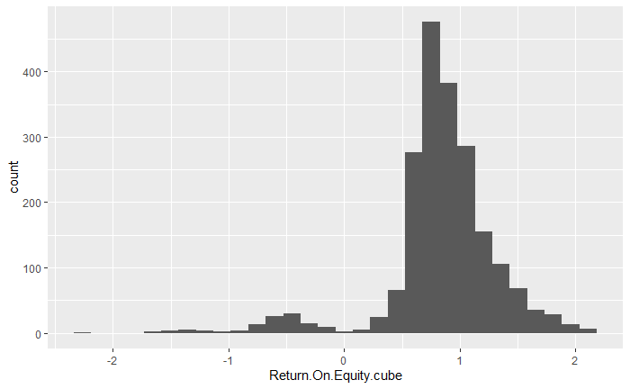

```r
tech$Return.On.Equity.cube <-  Math.cbrt(tech$Return.On.Equity)

ggplot(tech[tech$Return.On.Equity < 10,])+ geom_histogram(aes(x=Return.On.Equity.cube))
```

identify outliers

```r
sd <- sd(tech$Return.On.Equity.cube) # 0.5657205
mean <- mean(tech$Return.On.Equity.cube) #0.8724592
ci <- c(mean - 3*sd, mean + 3*sd) #-0.8247022  2.5696207
sum(!tech$Return.On.Equity.cube %between% ci)#30 outliers
```

```
[1] 30
```

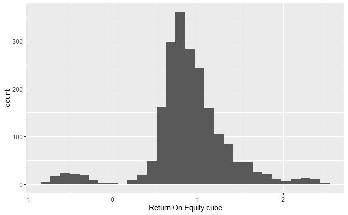

```r
ggplot(tech[tech$Return.On.Equity.cube %between% ci,]) + geom_histogram(aes(x = Return.On.Equity.cube))
```

```r
tech$Return.On.Equity.out <- !tech$Return.On.Equity.cube %between% ci
sum(tech$Return.On.Equity.out)
```

```
[1] 30
```

#############################################Receivable Turnover##########################################

```r
summary(tech$Receivable.Turnover)
```

```
     Min.   1st Qu.    Median      Mean   3rd Qu.      Max.
   0.2055    5.4420    6.9895   12.5850    9.3841 2829.0083
```

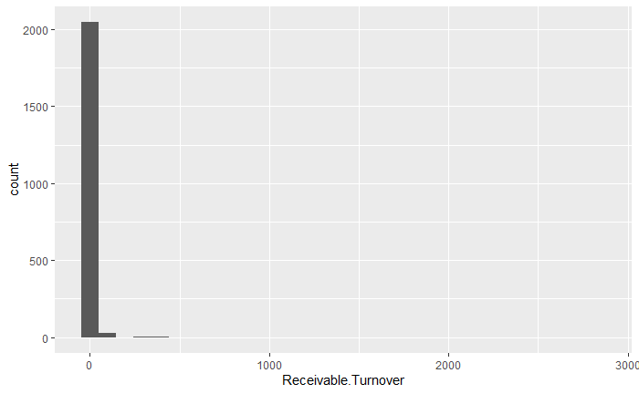

```r
#     Min.   1st Qu.    Median      Mean   3rd Qu.      Max.
#   0.2055    5.4420    6.9895   12.5850    9.3841 2829.0083

#check distribuion
ggplot(tech)+ geom_histogram(aes(x=Receivable.Turnover)）
```

After removing outliers, still right skewed

```r
sum(tech$Receivable.Turnover > 100) #16
```

```
[1] 16
```

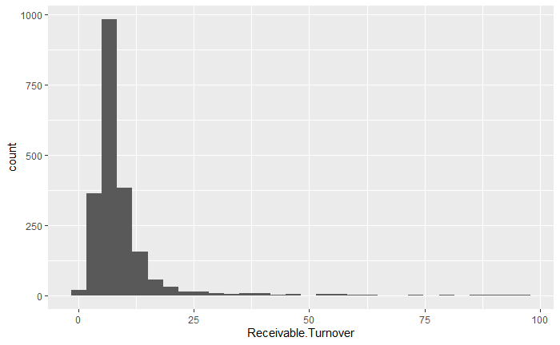

```r
ggplot(tech[tech$Receivable.Turnover < 100,])+ geom_histogram(aes(x=Receivable.Turnover))
```

Try log transformation, works pretty well

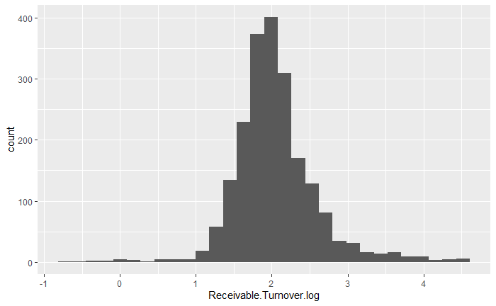

```r
tech$Receivable.Turnover.log <- Math.log(tech$Receivable.Turnover)
ggplot(tech[tech$Receivable.Turnover < 100,])+ geom_histogram(aes(x=Receivable.Turnover.log))
```

Compare with cube transformation, log works better

```r
#tech$Receivable.Turnover.cube <- Math.cbrt(tech$Receivable.Turnover)
#ggplot(tech[tech$Receivable.Turnover < 100,])+ geom_histogram(aes(x=Receivable.Turnover.cube))
```

identify outliers

```r
sd <- sd(tech$Receivable.Turnover.log) #  0.6323837
mean <- mean(tech$Receivable.Turnover.log) #2.075199
ci <- c(mean - 3*sd, mean + 3*sd) #0.1780484 3.9723505
sum(!tech$Receivable.Turnover.log %between% ci)#47 outliers
```

```
[1] 47
```

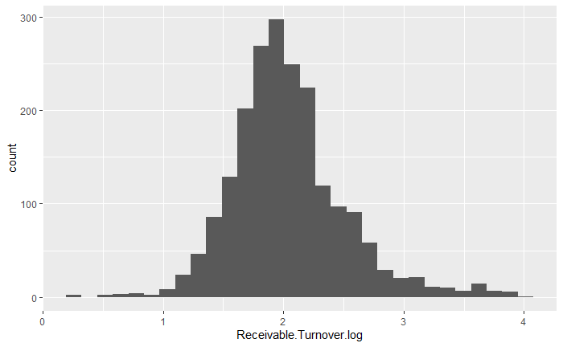

```r
ggplot(tech[tech$Receivable.Turnover.log %between% ci,])+ geom_histogram(aes(x=Receivable.Turnover.log))
```

```r
tech$Receivable.Turnover.out <- !tech$Receivable.Turnover.log %between% ci
sum(tech$Receivable.Turnover.out) #47
```

```
[1] 47
```

Book.to.Market Ratio

right skewed

```r
summary(tech$Book.to.Market.Ratio)
```

```
     Min.   1st Qu.    Median      Mean   3rd Qu.      Max.
   0.0042    0.1965    0.3437    2.8135    0.6151 1326.5407
```

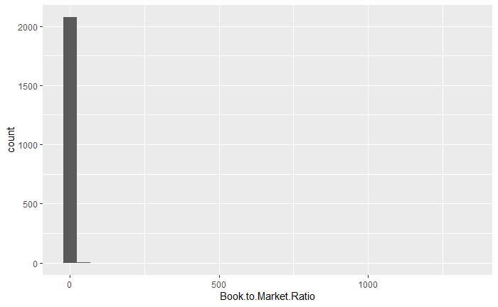

```r
#     Min.   1st Qu.    Median      Mean   3rd Qu.      Max.
#   0.0042    0.1965    0.3437    2.8135    0.6151 1326.5407

#check distribuion
ggplot(tech)+ geom_histogram(aes(x=Book.to.Market.Ratio))
```

removing several outliers, still right skewed distribution

```r
#the first histogram shows to be pretty rights skewed, so we set a arbitrary cut off at 10
sum(tech$Book.to.Market.Ratio > 10) #11
```

```
[1] 11
```

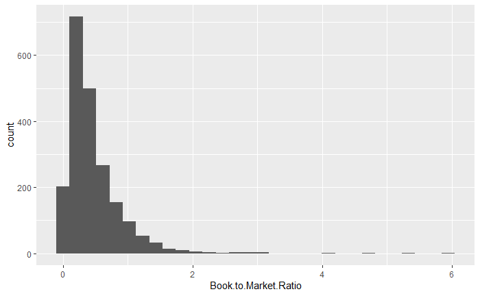

```r
#even after removing observations > 10 the data is still pretty right skewed
ggplot(tech[tech$Book.to.Market.Ratio <10,]) + geom_histogram(aes(x = Book.to.Market.Ratio))
```

Try cube transformation, doesn’t work so well

```r
#tech$Book.to.Market.Ratio.cube <- Math.cbrt(tech$Book.to.Market.Ratio)
#ggplot(tech) + geom_histogram(aes(x = Book.to.Market.Ratio.cube))
```

Try log transformation, works better, with wider range after removing observations 3sd more from the mean, the distribution is very symmetric

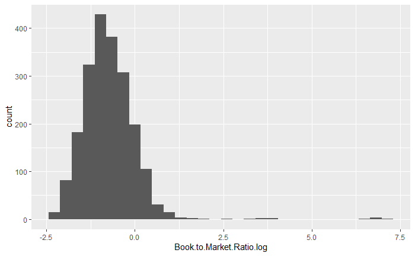

```r
tech$Book.to.Market.Ratio.log <- Math.log(tech$Book.to.Market.Ratio)
ggplot(tech) + geom_histogram(aes(x = Book.to.Market.Ratio.log))
```

```r
sd <- sd(tech$Book.to.Market.Ratio.log) # 0.7624426
mean <- mean(tech$Book.to.Market.Ratio.log) #-0.736918
ci <- c(mean - 3*sd, mean + 3*sd) #-3.024246  1.550410
sum(!tech$Book.to.Market.Ratio.log %between% ci)#14 outliers
```

```
[1] 14
```

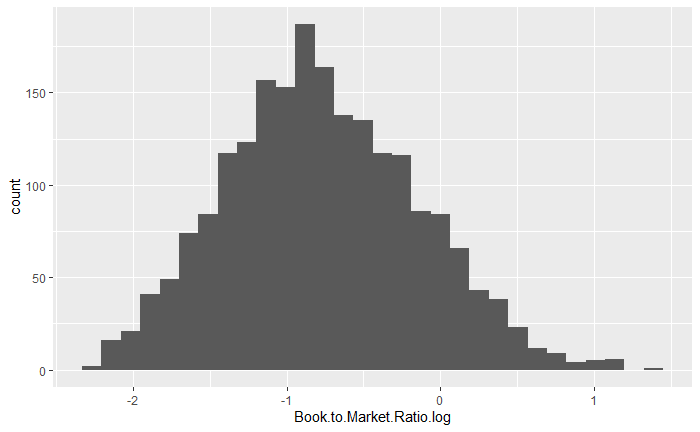

```r
ggplot(tech[tech$Book.to.Market.Ratio.log %between% ci,]) + geom_histogram(aes(x = Book.to.Market.Ratio.log))
```

```r
tech$Book.to.Market.Ratio.out <- !tech$Book.to.Market.Ratio.log %between% ci
sum(tech$Book.to.Market.Ratio.out)
```

```
[1] 14
```

Summary 1. log transformation 2. remove 14 outliers 3 sd away from mean

####################################################################write files #############################

| Ticker | SimFinId | Company.Name | Sector | Industry | Fiscal.Year | Operating.Profit.Margin | Operating.Profit.Margin.out | Return.On.Capital | Return.On.Capital.t | Return.On.Capital.out | Return.On.Equity | Return.On.Equity.t | Return.On.Equity.out | Book.to.Market.Ratio | Book.to.Market.Ratio.t | Book.to.Market.Ratio.out | Receivable.Turnover | Receivable.Turnover.t | Receivable.Turnover.out | Return | Return2 | Return3 | Return4 |
| --- | --- | --- | --- | --- | --- | --- | --- | --- | --- | --- | --- | --- | --- | --- | --- | --- | --- | --- | --- | --- | --- | --- | --- |
| AAOI | 671827 | APPLIED OPTOELECTRONICS, INC. | Technology | Semiconductors | 2013 | -0.0039146180 | FALSE | 0.7178055556 | 0.89536945 | FALSE | 0.819347781 | 0.9357419 | FALSE | 4.217111e-01 | -0.642657930 | FALSE | 5.7984473 | 1.80893844 | FALSE | -0.2459677419 | 0.2540792541 | 0.2264016412 | 1.2540793 |
| AAOI | 671827 | APPLIED OPTOELECTRONICS, INC. | Technology | Semiconductors | 2014 | 0.0393870401 | FALSE | 0.6352848160 | 0.85965229 | FALSE | 0.740548812 | 0.9047277 | FALSE | 6.749622e-01 | -0.249559569 | FALSE | 5.9056091 | 1.82634221 | FALSE | 0.5212765957 | 0.2807453416 | 0.2474422066 | 1.2807453 |
| AAOI | 671827 | APPLIED OPTOELECTRONICS, INC. | Technology | Semiconductors | 2015 | 0.0708203662 | FALSE | 0.6693999348 | 0.87477270 | FALSE | 0.806992829 | 0.9310147 | FALSE | 5.829956e-01 | -0.375162983 | FALSE | 6.0116813 | 1.84327579 | FALSE | 0.3820754717 | -0.0674102813 | -0.0697899190 | 0.9325897 |
| AAOI | 671827 | APPLIED OPTOELECTRONICS, INC. | Technology | Semiconductors | 2016 | 0.0882963258 | FALSE | 0.6959957308 | 0.88620771 | FALSE | 0.803007248 | 0.9294795 | FALSE | 5.476612e-01 | -0.427951745 | FALSE | 6.7237395 | 1.95008093 | FALSE | 0.5951075496 | 1.1163636364 | 0.7496993501 | 2.1163636 |
| AAOI | 671827 | APPLIED OPTOELECTRONICS, INC. | Technology | Semiconductors | 2017 | 0.2274245480 | FALSE | 0.7393061558 | 0.90422139 | FALSE | 0.848002856 | 0.9465258 | FALSE | 4.375648e-01 | -0.612957125 | FALSE | 7.6825343 | 2.07794683 | FALSE | -0.5917989418 | -0.5142291512 | -0.7220182708 | 0.4857708 |
| AAOI | 671827 | APPLIED OPTOELECTRONICS, INC. | Technology | Semiconductors | 2018 | -0.0402594732 | FALSE | 0.3575196060 | 0.70974110 | FALSE | 0.423058457 | 0.7507007 | FALSE | 1.085570e+00 | 0.173744558 | FALSE | 4.4689223 | 1.56327653 | FALSE | -0.1866666667 | -0.3465452598 | -0.4254820058 | 0.6534547 |
| AAPL | 111052 | APPLE INC | Technology | Computer Hardware | 2009 | 0.2736277823 | FALSE | 0.9787554733 | 0.99286774 | FALSE | 1.159576485 | 1.0505897 | FALSE | 1.655373e-01 | -1.310374513 | FALSE | 17.7146986 | 2.89149421 | FALSE | 0.5113151853 | 0.5857720834 | 0.4610714076 | 1.5857721 |
| AAPL | 111052 | APPLE INC | Technology | Computer Hardware | 2010 | 0.2818704484 | FALSE | 0.9891618784 | 0.99637416 | FALSE | 1.190579816 | 1.0598706 | FALSE | 1.602246e-01 | -1.330268403 | FALSE | 19.4064267 | 2.98122473 | FALSE | 0.2437037833 | 0.3393546624 | 0.2921879027 | 1.3393547 |
| AAPL | 111052 | APPLE INC | Technology | Computer Hardware | 2011 | 0.3121506896 | FALSE | 1.0651148709 | 1.02125019 | FALSE | 1.258330614 | 1.0796051 | FALSE | 2.019687e-01 | -1.183678724 | FALSE | 19.6459165 | 2.99330099 | FALSE | 0.3905057134 | 0.5446753645 | 0.4348137682 | 1.5446754 |
| AAPL | 111052 | APPLE INC | Technology | Computer Hardware | 2012 | 0.3529595931 | FALSE | 1.1827256577 | 1.05753481 | FALSE | 1.182725658 | 1.0575348 | FALSE | 2.349669e-01 | -1.081316907 | FALSE | 29.1503073 | 3.38289166 | FALSE | 0.1621469948 | 0.0071577346 | 0.0071322396 | 1.0071577 |

[output cut: 990 more lines]

############################################################write files to local####################################

[figure not shown]